# Intro to Rmarkdown

@rodriguezmDNA

[tl;dr click here](https://rstudio.com/wp-content/uploads/2016/03/rmarkdown-cheatsheet-2.0.pdf)

Rmarkdown offers a way to combine plain text and results from your analysis in a powerful way. The output can be a PDF, static webpage (HTML document) or a Word doc. There are many ways to customize it but here I’ll just present the very basics.

One of the features of markdown is that you can format plain text easily without the need of knowing more complex (albeit more powerful) markup languages.

Rmarkdown interprets each line as simple text *unless* it encounters a chunk of code. A chunk of code is surrounded by

`` ```{r} ``  
`#Your R code goes here`  
`library(tidyverse)`  
`plot(cars)`  
`` ``` ``

Next, is how to format your text. Markdown is quite elegant in the way it handles the formatting. Surround text between two underscores `_` to make it *italics* or between double asterisks `**` to **bold** . You can even **combine** both. To make a list just add an asterisk to the start of each line:

- `**bold**` = **bold**
- `_italics_` = *italics*
- `_**both**_` = *both*

Also works for numbered lists

1. Uno
2. Dos
3. Tres
4. [Catorce](https://www.youtube.com/watch?v=98W9QuMq-2k)

(^ you can also include links to websites)

Add three dashes (`---`) to print lines to separate your text:

To write a titles just add `#` at the start of the line:

# Titlest of all titles that ever titled

## Such chapter, so title, much impressed

### Sir Title Titlebaum, Third of its Rank

### Maybe important

#### Srsly?

##### I’d argue against this

To convert your Rmarkdown file to a nicely HTML or PDF, click the **Knit** button below the script’s tab (top border in RStudio). All your text and R code will be run together to produce the output.

All of your Rcode has to be exactly the same as in a normal R script. You need ot load the libraries

```r
library(tidyverse)
```

Check the contents of data:

```r
head(mpg)
```

| manufacturer | model | displ | year | cyl | trans | drv | cty | hwy | fl | class |
| --- | --- | --- | --- | --- | --- | --- | --- | --- | --- | --- |
| audi | a4 | 1.8 | 1999 | 4 | auto(l5) | f | 18 | 29 | p | compact |
| audi | a4 | 1.8 | 1999 | 4 | manual(m5) | f | 21 | 29 | p | compact |
| audi | a4 | 2.0 | 2008 | 4 | manual(m6) | f | 20 | 31 | p | compact |
| audi | a4 | 2.0 | 2008 | 4 | auto(av) | f | 21 | 30 | p | compact |
| audi | a4 | 2.8 | 1999 | 6 | auto(l5) | f | 16 | 26 | p | compact |
| audi | a4 | 2.8 | 1999 | 6 | manual(m5) | f | 18 | 26 | p | compact |

You can also add plots:

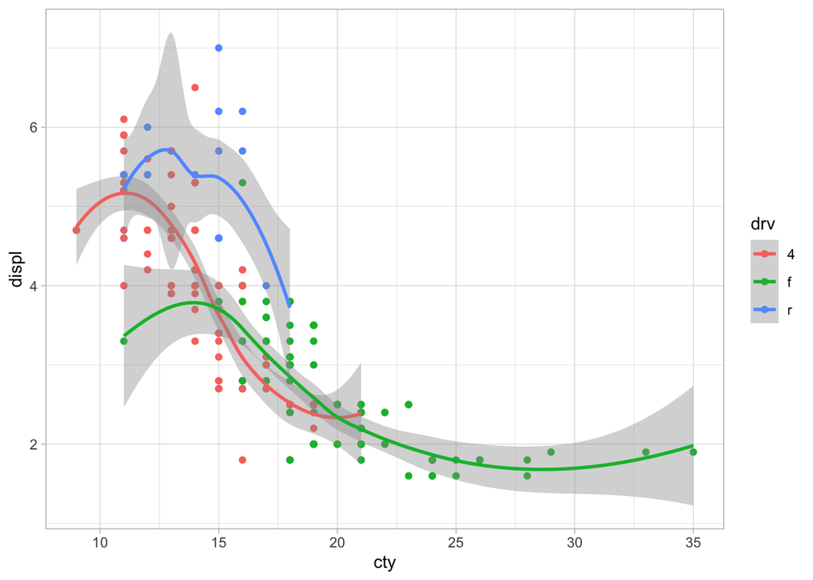

```r
ggplot(mpg,aes(x=cty,y=displ,color=drv)) +
  geom_point() +
  geom_smooth() +
  theme_light()
```

You can have finer control of the behaviour of the chunks. Adding parameters to the `{r}` portion you can. For example, adding `echo=F` and `message=F` won’t output the code that produced the plot or any messages (like the ones `geom_smooth()` produces):

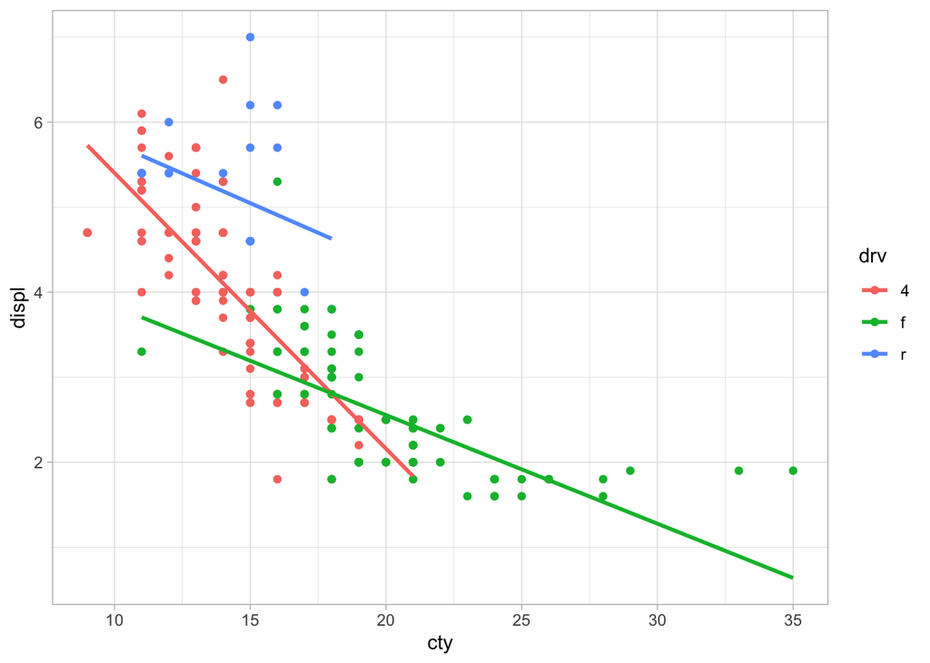

### More

This barely scratches the surface of what you can do with Rmarkdown but it’s enough to make reproducible code.

To know more about all the fancy stuff that RMD (that’s how the cool kids call it) is capable of doing check out [The Definitive Guide](https://bookdown.org/yihui/rmarkdown/)

And more on markdown syntax on how to format your text:

- [Markdown syntax](https://www.markdownguide.org/basic-syntax)
- [Original markdown project](https://daringfireball.net/projects/markdown/)